# **Sentiment Analysis** **(Part - 1)**

## Correlation

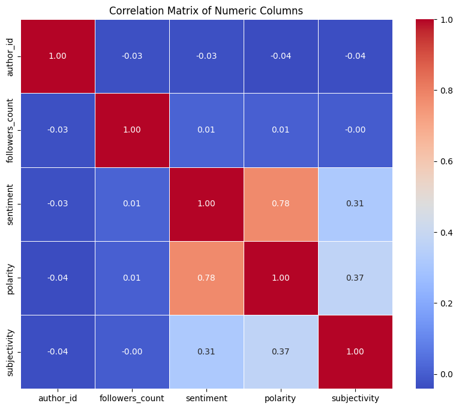

```python
import pandas as pd
import seaborn as sns
import matplotlib.pyplot as plt

# Assuming df is your DataFrame with numeric columns
numeric_columns = df.select_dtypes(include='number')

# Calculate the correlation matrix
correlation_matrix = numeric_columns.corr()

# Plotting the correlation matrix using a heatmap
plt.figure(figsize=(10, 8))
sns.heatmap(correlation_matrix, annot=True, cmap='coolwarm', fmt='.2f', linewidths=.5)
plt.title('Correlation Matrix of Numeric Columns')
plt.show()
```

# Text Pre Processing

## Check for null values and remove them

```python
# Getting  regular expressions Library
import re

# Function to remove stock tags to make sentences simple
def remove_words_except_stocktag(text):
    if pd.isna(text):
        return text

    words = text.split()
    filtered_words = [word for word in words if not word.startswith('$') or word == '$MSFT']
    return ' '.join(filtered_words)

# Apply the custom function to the 'text' column
df['cleaned_text'] = df['text'].apply(remove_words_except_stocktag)
```

```python
# Function to remove URLs from the text
def remove_urls_and_twitter(text):
    if pd.isna(text):
        return text

    # Remove URLs starting with http/https and Twitter-like patterns
    cleaned_text = re.sub(r'http[s]?://(?:[a-zA-Z]|[0-9]|[$-_@.&+]|[!*\\(\\),]|(?:%[0-9a-fA-F][0-9a-fA-F]))+|//twitter\.com/\S+|pic\.twitter\.com/\S+', '', text)
    return cleaned_text.strip()

# Apply the custom function to the 'text' column
df['cleaned_text'] = df['text'].apply(remove_urls_and_twitter)
```

```python
# Check for null values in the DataFrame
null_values = df.isnull().sum()
# Display the columns with null values (if any)
print("Columns with null values:")
print(null_values[null_values > 0])
```

```
Columns with null values:
Series([], dtype: int64)
```

```python
# Remove rows with null values
df = df.dropna()
```

```python
df.shape
```

```
(62871, 9)
```

```python
df.head()
```

|  | Date | author_id | name | text | followers_count | sentiment | polarity | subjectivity | cleaned_text |
| --- | --- | --- | --- | --- | --- | --- | --- | --- | --- |
| 0 | 2017-09-08 | 4825963711 | Software News | #IBM #and MIT team up to launch an AI lab set ... | 915.0 | 1 | 0.50 | 0.50 | #IBM #and MIT team up to launch an AI lab set ... |
| 1 | 2017-09-08 | 4825027321 | IT Services News | #IBM #to invest $240 million to advance artifi... | 1441.0 | -1 | -0.05 | 0.75 | #IBM #to invest $240 million to advance artifi... |
| 2 | 2017-09-08 | 4825027321 | IT Services News | #IBM #To Invest $240M In AI Lab From MIT. Read... | 1441.0 | 1 | 0.50 | 0.50 | #IBM #To Invest $240M In AI Lab From MIT. Read... |
| 3 | 2017-09-08 | 706297891070087168 | OptionsPro MaxPain | #Options #maxpain chart for $IBM. Free options... | 3077.0 | 1 | 0.40 | 0.80 | #Options #maxpain chart for $IBM. Free options... |
| 4 | 2017-09-08 | 4825027321 | IT Services News | #IBM #and MIT team up to launch an AI lab set ... | 1441.0 | 1 | 0.50 | 0.50 | #IBM #and MIT team up to launch an AI lab set ... |

## Checking Missing Values and Dublicates

```python
# Function for Missing Value/Empty Values in whole dataframe
def missing_value_analysis(dataframe):
    # Check for missing values in the dataframe
    missing_values = dataframe.isnull().sum()

    # Print the missing values for each feature
    print("Missing Values Analysis:")
    print(missing_values[missing_values > 0])

# Apply missing value analysis to your social media dataset
missing_value_analysis(df)
```

```
Missing Values Analysis:
Series([], dtype: int64)
```

```python
# Function for Duplicated Variable Analysis
def duplicated_variable_analysis(dataframe):
    # Check for duplicated columns
    duplicated_columns = dataframe.columns[dataframe.T.duplicated()]

    # Print the duplicated columns
    print("Duplicated Variable Analysis:")
    print(duplicated_columns)

    # Remove duplicated columns from the dataframe
    dataframe = dataframe.loc[:, ~dataframe.columns.duplicated()]

    return dataframe

# Apply duplicated variable analysis to your social media dataset
df = duplicated_variable_analysis(df)
```

```
Duplicated Variable Analysis:
Index([], dtype='object')
```

## Removing Links and urls

```python
#Importing necessery Libraries for cleaning texts
from html import unescape
from nltk.tokenize import TweetTokenizer
from nltk.corpus import stopwords
from nltk.stem import WordNetLemmatizer

# Download NLTK resources
import nltk
nltk.download('stopwords')
nltk.download('wordnet')

# Instantiate the lemmatizer and tokenizer for text
lemmatizer = WordNetLemmatizer()
tokenizer = TweetTokenizer()

# Get English stopwords
stop_words = set(stopwords.words('english'))

def clean_text(text):
    # Remove HTML encodings
    text = unescape(text)

    # Remove user IDs
    text = re.sub(r'@[^\s]+', '', text)

    # Remove retweet symbols
    text = re.sub(r'^RT[\s]+', '', text)

    # Replace URLs in different forms
    text = re.sub(r'http[s]?://(?:[a-zA-Z]|[0-9]|[$-_@.&+]|[!*\\(\\),]|(?:%[0-9a-fA-F][0-9a-fA-F]))+', '_url', text)

    # Tokenize and lemmatize the senteces into words
    words = tokenizer.tokenize(text)
    words = [lemmatizer.lemmatize(word) for word in words]

    # Remove stopwords
    words = [word for word in words if word.lower() not in stop_words]

    # Join the cleaned words back into a sentence
    cleaned_text = ' '.join(words)

    return cleaned_text

# Apply the cleaning function to the 'cleaned_text' column
df['cleaned_text'] = df['cleaned_text'].apply(clean_text)
```

## Checking Spellings and Contractions

```python
# Function to normalize the elongated words
def correct_word_elongation(text):
    # Correct word elongation, e.g., 'victoryyyyy' to 'victory'
    text = re.sub(r'(\w)\1+', r'\1\1', text)
    return text

# Function for
def correct_contractions(text):
    # Correct common word contractions
    text = re.sub(r"won't", "will not", text)
    text = re.sub(r"can't", "cannot", text)
    text = re.sub(r"don't", "do not", text)
    text = re.sub(r"shouldn't", "should not", text)
    text = re.sub(r"didn't", "did not", text)
    return text

# def clean_numeric_symbols(text):
#     # Remove unnecessary apostrophes and punctuation splits from the last word in a sentence
#     text = re.sub(r"'\s", "", text)
#     text = re.sub(r"(\S+)'\Z", r"\1", text)

#     # Verify numeric value types, such as float and whole numbers
#     # Join symbols with their respective words, e.g., '$ AAPL' to '$AAPL'
#     text = re.sub(r'(\$)\s?([A-Za-z]+)', r'\1\2', text)

#     return text

# Apply the all above functions to the 'cleaned_text' column
# df['cleaned_text'] = df['cleaned_text'].apply(correct_spelling_mistakes)
df['cleaned_text'] = df['cleaned_text'].apply(correct_word_elongation)
df['cleaned_text'] = df['cleaned_text'].apply(correct_contractions)
df['cleaned_text'] = df['cleaned_text'].apply(clean_numeric_symbols)
```

```python
# Function to correct the end of words
def correct_apostrophes_and_punctuation(text):
    # Correct unnecessary apostrophes at the end of words
    text = re.sub(r'(\w+)’', r'\1\'', text)

    # Correct punctuation splits from the last word in a sentence
    text = re.sub(r'(\w+)([.,;!?])\s*$', r'\1\2', text)

    return text

df['cleaned_text'] = df['cleaned_text'].apply(correct_apostrophes_and_punctuation)
```

```python
# Getting Library for for pluralizing and singularizing English words
import inflect

# Function to convert extensions in integers
def convert_ordinal_words(text):
    # Initialize the inflect engine
    p = inflect.engine()

    # Split the text into words and process each word
    words = text.split()
    for i, word in enumerate(words):
        # Check if the word is an ordinal word (e.g., '1st', '#1')
        if word.lower() in ['1st', '#1', '2nd', '3rd'] or word.lower().endswith(('th', 'nd', 'rd', 'st')):
            # Extract the numeric part before 'st', 'nd', 'rd', or 'th'
            numeric_part = word[:-2] if word[:-2].isdigit() else word[:-3]

            try:
                # Convert the ordinal word to its numeric counterpart
                numeric_representation = p.ordinal(int(numeric_part))
                words[i] = numeric_representation
            except ValueError:
                # Handle the case where conversion to int fails
                pass

    # Rejoin the words to form the corrected text
    corrected_text = ' '.join(words)

    return corrected_text

df['cleaned_text'] = df['cleaned_text'].apply(convert_ordinal_words)
```

```python
df.head()
```

|  | Date | author_id | name | text | followers_count | sentiment | polarity | subjectivity | cleaned_text |
| --- | --- | --- | --- | --- | --- | --- | --- | --- | --- |
| 0 | 2017-09-08 | 4825963711 | Software News | #IBM #and MIT team up to launch an AI lab set ... | 915.0 | 1 | 0.50 | 0.50 | #IBM #and MIT team launch AI lab set make Wats... |
| 1 | 2017-09-08 | 4825027321 | IT Services News | #IBM #to invest $240 million to advance artifi... | 1441.0 | -1 | -0.05 | 0.75 | #IBM #to invest $ 240 million advance artifici... |
| 2 | 2017-09-08 | 4825027321 | IT Services News | #IBM #To Invest $240M In AI Lab From MIT. Read... | 1441.0 | 1 | 0.50 | 0.50 | #IBM #To Invest $ 240M AI Lab MIT . Read : $IBM |
| 3 | 2017-09-08 | 706297891070087168 | OptionsPro MaxPain | #Options #maxpain chart for $IBM. Free options... | 3077.0 | 1 | 0.40 | 0.80 | #Options #maxpain chart $IBM . Free option app |
| 4 | 2017-09-08 | 4825027321 | IT Services News | #IBM #and MIT team up to launch an AI lab set ... | 1441.0 | 1 | 0.50 | 0.50 | #IBM #and MIT team launch AI lab set make Wats... |

Removing the other specific URLs like twitter.com

```python
# Function to remove specific patterns
def remove_patterns(text):
    patterns_to_remove = [
        r'pic.twitter.com/\S+',  # Remove pic.twitter.com URLs
        r'\$\w+',                # Remove $ followed by a name
        r'https://twitter.com/\S+',  # Remove Twitter URLs
        r'http[s]?://\S+',       # Remove other URLs
        r'\d+'                   # Remove numbers
    ]
    for pattern in patterns_to_remove:
        text = re.sub(pattern, '', text)
    return text

# Apply the function to the 'text' column
df['cleaned_text'] = df['cleaned_text'].apply(remove_patterns)
```

Removing different URLs patterns

```python
#  Function to remove specific patterns in URLs
def remove_patterns(text):
    patterns_to_remove = [
        r'pic.twitter.com/\S+',  # Remove pic.twitter.com URLs
        r'\$\w+',                # Remove $ followed by a name
        r'https://twitter.com/\S+',  # Remove Twitter URLs
        r'http[s]?://\S+',       # Remove other URLs
        r'\d+',                  # Remove numbers
        r'#\w+',                 # Remove hashtags
        r'\(Min[^)]+\)',         # Remove patterns like (Min , Daily EMA > , Close > EMA, Vol > K, Opt Vol in any strike > )
        r'-{2,}',                # Remove consecutive dashes
        r'\d+\%',                # Remove percentages
        r'\.\.\.+',              # Remove ellipses
        r'@\w+',                 # Remove mentions
        r',\s+',                 # Remove commas followed by spaces
        r'\s+[.,]+',             # Remove spaces followed by dots or commas
        r'\s+\.{3}',             # Remove spaces followed by three dots
        r'\s+[^\w\s]',           # Remove other non-alphanumeric characters
    ]
    for pattern in patterns_to_remove:
        text = re.sub(pattern, ' ', text)
    return text.strip()

# Apply the function to the 'text' column
df['cleaned_text'] = df['cleaned_text'].apply(remove_patterns)
```

## Spacy for Core Meaning Extraction

```python
!pip install spacy
```

```python
import pandas as pd
import spacy

# Load spaCy model from web
nlp = spacy.load("en_core_web_sm")

# Function to extract the core meaning from text
def extract_core_meaning(text):
    doc = nlp(text)
    core_meaning = ' '.join([token.lemma_ for token in doc if token.pos_ not in ('PUNCT', 'SPACE')])

    return core_meaning

# Apply the function to the 'cleaned_text' column
df['core_meaning'] = df['cleaned_text'].apply(extract_core_meaning)
```

```python
df.head()
```

[output not shown]

## Tokenization

```python
#If the Spacy is taking too long time you can use this code to directly assign cleaned code as core meaning because it's almost neat
df['core_meaning'] = df['cleaned_text']
```

```python
#mporting Tokenization Libraries

from bs4 import BeautifulSoup              # Parsing HTML content

import nltk                                # Natural Language Toolkit for working with human language data
from nltk.tokenize import word_tokenize    # tokenizing sentences into words
from nltk.corpus import stopwords          # Remove common words
from nltk.stem import PorterStemmer        # For stemming, reducing words to their base or root form


nltk.download('punkt')

# Tokenization of sentences into words
df['tokens'] = df['core_meaning'].apply(lambda x: word_tokenize(x))

# Removing Stop Words
stop_words = set(stopwords.words('english'))
df['tokens'] = df['tokens'].apply(lambda x: [word for word in x if word.lower() not in stop_words])
```

```python
# Joining Tokens and finalizing it as clean tweets
df['clean_tweets'] = df['tokens'].apply(lambda x: ' '.join(x))
```

```python
df.head()
```

|  | Date | author_id | name | text | followers_count | sentiment | polarity | subjectivity | cleaned_text | core_meaning | tokens | clean_tweets |
| --- | --- | --- | --- | --- | --- | --- | --- | --- | --- | --- | --- | --- |
| 0 | 2017-09-08 | 4825963711 | Software News | #IBM #and MIT team up to launch an AI lab set ... | 915.0 | 1 | 0.50 | 0.50 | MIT team launch AI lab set make Watson even sm... | MIT team launch AI lab set make Watson even sm... | [MIT, team, launch, AI, lab, set, make, Watson... | MIT team launch AI lab set make Watson even sm... |
| 1 | 2017-09-08 | 4825027321 | IT Services News | #IBM #to invest $240 million to advance artifi... | 1441.0 | -1 | -0.05 | 0.75 | invest million advance artificial intelligen... | invest million advance artificial intelligen... | [invest, million, advance, artificial, intelli... | invest million advance artificial intelligence... |
| 2 | 2017-09-08 | 4825027321 | IT Services News | #IBM #To Invest $240M In AI Lab From MIT. Read... | 1441.0 | 1 | 0.50 | 0.50 | Invest M AI Lab MIT Read | Invest M AI Lab MIT Read | [Invest, AI, Lab, MIT, Read] | Invest AI Lab MIT Read |
| 3 | 2017-09-08 | 706297891070087168 | OptionsPro MaxPain | #Options #maxpain chart for $IBM. Free options... | 3077.0 | 1 | 0.40 | 0.80 | chart Free option app | chart Free option app | [chart, Free, option, app] | chart Free option app |
| 4 | 2017-09-08 | 4825027321 | IT Services News | #IBM #and MIT team up to launch an AI lab set ... | 1441.0 | 1 | 0.50 | 0.50 | MIT team launch AI lab set make Watson even sm... | MIT team launch AI lab set make Watson even sm... | [MIT, team, launch, AI, lab, set, make, Watson... | MIT team launch AI lab set make Watson even sm... |

# VADER Sentiment Analysis

```python
# Import the SentimentIntensityAnalyzer from the NLTK's VADER module
from nltk.sentiment.vader import SentimentIntensityAnalyzer

# Import the nltk library
import nltk

# Download the VADER lexicon which is a pre-built list of words and their sentiment scores
nltk.download('vader_lexicon')

# Initialize the VADER sentiment analyzer
sia = SentimentIntensityAnalyzer()
```

```python
# Function to apply VADER sentiment analysis and create 'vader_sentiment_score' column
def get_vader_sentiment(row):
    # Use the VADER sentiment analyzer on the cleaned text
    sentiment_scores = sia.polarity_scores(row['clean_tweets'])

    # Assign the compound sentiment score to a new column 'vader_sentiment_score'
    row['vader_sentiment_score'] = sentiment_scores['compound']

    return row
```

```python
# Apply the function to each row in the DataFrame
df = df.apply(get_vader_sentiment, axis=1)
```

```python
df.head()
```

|  | Date | author_id | name | text | followers_count | sentiment | polarity | subjectivity | cleaned_text | core_meaning | tokens | clean_tweets | vader_sentiment_score |
| --- | --- | --- | --- | --- | --- | --- | --- | --- | --- | --- | --- | --- | --- |
| 0 | 2017-09-08 | 4825963711 | Software News | #IBM #and MIT team up to launch an AI lab set ... | 915.0 | 1 | 0.50 | 0.50 | MIT team launch AI lab set make Watson even sm... | MIT team launch AI lab set make Watson even sm... | [MIT, team, launch, AI, lab, set, make, Watson... | MIT team launch AI lab set make Watson even sm... | 0.4588 |
| 1 | 2017-09-08 | 4825027321 | IT Services News | #IBM #to invest $240 million to advance artifi... | 1441.0 | -1 | -0.05 | 0.75 | invest million advance artificial intelligen... | invest million advance artificial intelligen... | [invest, million, advance, artificial, intelli... | invest million advance artificial intelligence... | 0.4767 |
| 2 | 2017-09-08 | 4825027321 | IT Services News | #IBM #To Invest $240M In AI Lab From MIT. Read... | 1441.0 | 1 | 0.50 | 0.50 | Invest M AI Lab MIT Read | Invest M AI Lab MIT Read | [Invest, AI, Lab, MIT, Read] | Invest AI Lab MIT Read | 0.0000 |
| 3 | 2017-09-08 | 706297891070087168 | OptionsPro MaxPain | #Options #maxpain chart for $IBM. Free options... | 3077.0 | 1 | 0.40 | 0.80 | chart Free option app | chart Free option app | [chart, Free, option, app] | chart Free option app | 0.5106 |
| 4 | 2017-09-08 | 4825027321 | IT Services News | #IBM #and MIT team up to launch an AI lab set ... | 1441.0 | 1 | 0.50 | 0.50 | MIT team launch AI lab set make Watson even sm... | MIT team launch AI lab set make Watson even sm... | [MIT, team, launch, AI, lab, set, make, Watson... | MIT team launch AI lab set make Watson even sm... | 0.4588 |

# TextBlob Sentiment Analysis

```python
# Import the TextBlob class from the textblob module
from textblob import TextBlob

# Function to get sentiment score using TextBlob
def get_sentiment_score(tweet):
    # Check if the tweet is empty or NaN
    if not tweet or pd.isnull(tweet):
        return None

    # Create a TextBlob object for the tweet
    blob = TextBlob(tweet)

    # Return the sentiment polarity score
    return blob.sentiment.polarity

# Apply the TextBlob sentiment analysis and create 'TextBlob_sentiment_score' column
df['TextBlob_sentiment_score'] = df['clean_tweets'].apply(get_sentiment_score)
```

```python
df.head()
```

|  | Date | author_id | name | text | followers_count | sentiment | polarity | subjectivity | cleaned_text | core_meaning | tokens | clean_tweets | vader_sentiment_score | TextBlob_sentiment_score |
| --- | --- | --- | --- | --- | --- | --- | --- | --- | --- | --- | --- | --- | --- | --- |
| 0 | 2017-09-08 | 4825963711 | Software News | #IBM #and MIT team up to launch an AI lab set ... | 915.0 | 1 | 0.50 | 0.50 | MIT team launch AI lab set make Watson even sm... | MIT team launch AI lab set make Watson even sm... | [MIT, team, launch, AI, lab, set, make, Watson... | MIT team launch AI lab set make Watson even sm... | 0.4588 | 0.0 |
| 1 | 2017-09-08 | 4825027321 | IT Services News | #IBM #to invest $240 million to advance artifi... | 1441.0 | -1 | -0.05 | 0.75 | invest million advance artificial intelligen... | invest million advance artificial intelligen... | [invest, million, advance, artificial, intelli... | invest million advance artificial intelligence... | 0.4767 | -0.6 |
| 2 | 2017-09-08 | 4825027321 | IT Services News | #IBM #To Invest $240M In AI Lab From MIT. Read... | 1441.0 | 1 | 0.50 | 0.50 | Invest M AI Lab MIT Read | Invest M AI Lab MIT Read | [Invest, AI, Lab, MIT, Read] | Invest AI Lab MIT Read | 0.0000 | 0.0 |
| 3 | 2017-09-08 | 706297891070087168 | OptionsPro MaxPain | #Options #maxpain chart for $IBM. Free options... | 3077.0 | 1 | 0.40 | 0.80 | chart Free option app | chart Free option app | [chart, Free, option, app] | chart Free option app | 0.5106 | 0.4 |
| 4 | 2017-09-08 | 4825027321 | IT Services News | #IBM #and MIT team up to launch an AI lab set ... | 1441.0 | 1 | 0.50 | 0.50 | MIT team launch AI lab set make Watson even sm... | MIT team launch AI lab set make Watson even sm... | [MIT, team, launch, AI, lab, set, make, Watson... | MIT team launch AI lab set make Watson even sm... | 0.4588 | 0.0 |

# Ploting all Sentiment Scores

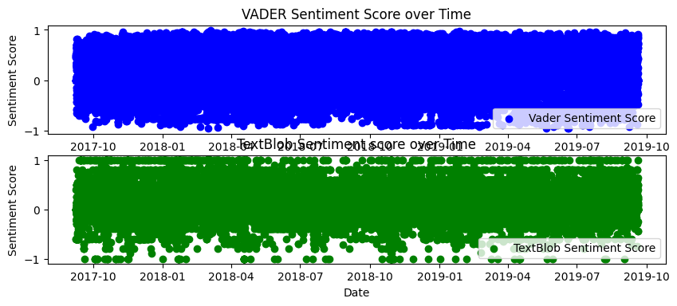

```python
# Defining the figure size
plt.figure(figsize=(10, 6))

# Plotting Vader Sentiment Score
plt.subplot(3, 1, 1)
plt.scatter(df['Date'], df['vader_sentiment_score'], color='blue', label='Vader Sentiment Score')
plt.title('VADER Sentiment Score over Time')
plt.xlabel('Date')
plt.ylabel('Sentiment Score')
plt.legend()

# Plotting TextBlob Sentiment Score
plt.subplot(3, 1, 2)
plt.scatter(df['Date'], df['TextBlob_sentiment_score'], color='green', label='TextBlob Sentiment Score')
plt.title('TextBlob Sentiment score over Time')
plt.xlabel('Date')
plt.ylabel('Sentiment Score')
plt.legend()
```

[figure not shown]

```python
import pandas as pd
import matplotlib.pyplot as plt

# Assuming 'Date' column is in datetime format
df['Date'] = pd.to_datetime(df['Date'])

# Weekly aggregation of sentiment scores
df_weekly = df.groupby(df['Date'].dt.to_period("W")).mean().reset_index()

# Convert 'Date' to string
df_weekly['Date'] = df_weekly['Date'].astype(str)

# Defining the figure size
plt.figure(figsize=(10, 12))  # Increase figure height for gaps

# Plotting Vader Sentiment Score
plt.subplot(3, 1, 1)
plt.plot(df_weekly['Date'], df_weekly['vader_sentiment_score'], color='blue', label='Vader Sentiment Score', marker='o')
plt.title('Weekly Aggregated VADER Sentiment Score')
plt.xlabel('Date')
plt.ylabel('Sentiment Score')
plt.legend()
plt.xticks(rotation=45)  # Rotate x-axis labels

# Add some space between subplots
plt.subplots_adjust(hspace=0.5)

# Plotting TextBlob Sentiment Score
plt.subplot(3, 1, 2)
plt.plot(df_weekly['Date'], df_weekly['TextBlob_sentiment_score'], color='green', label='TextBlob Sentiment Score', marker='o')
plt.title('Weekly Aggregated TextBlob Sentiment Score')
plt.xlabel('Date')
plt.ylabel('Sentiment Score')
plt.legend()
plt.xticks(rotation=45)  # Rotate x-axis labels

plt.tight_layout()
plt.show()
```

# Final Sentiment Score

```python
# Make a new column final_sentiment_score by meaning the three sentiment scores
# Define weights for each sentiment score
vader_weight = 0.7
textblob_weight = 0.3


# Calculate the weighted average
df['final_sentiment_score'] = (df['vader_sentiment_score'] * vader_weight +
                               df['TextBlob_sentiment_score'] * textblob_weight)
```

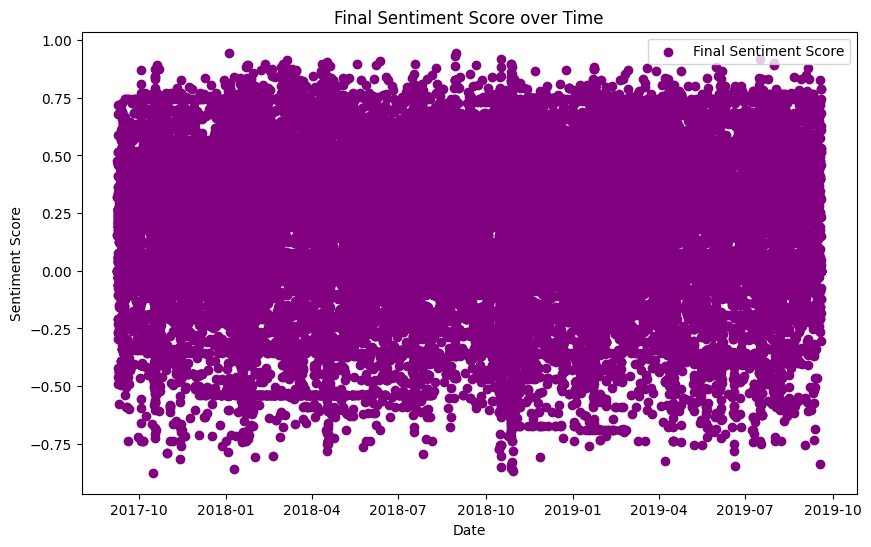

```python
# Plotting 'final_sentiment_score' over time
plt.figure(figsize=(10, 6))
plt.scatter(df['Date'], df['final_sentiment_score'], color='purple', label='Final Sentiment Score')
plt.title('Final Sentiment Score over Time')
plt.xlabel('Date')
plt.ylabel('Sentiment Score')
plt.legend()
plt.show()
```

[figure not shown]

```python
import pandas as pd
import matplotlib.pyplot as plt

# Assuming 'Date' column is in datetime format
df['Date'] = pd.to_datetime(df['Date'])

# Weekly aggregation of final_sentiment_score
df_weekly_final = df.groupby(df['Date'].dt.to_period("W")).mean().reset_index()

# Convert 'Date' to string
df_weekly_final['Date'] = df_weekly_final['Date'].astype(str)

# Defining the figure size
plt.figure(figsize=(10, 6))

# Plotting Final Sentiment Score
plt.plot(df_weekly_final['Date'], df_weekly_final['final_sentiment_score'], color='purple', label='Final Sentiment Score', marker='o')
plt.title('Weekly Aggregated Final Sentiment Score')
plt.xlabel('Date')
plt.ylabel('Sentiment Score')
plt.legend()
plt.xticks(rotation=45)  # Rotate x-axis labels

plt.tight_layout()
plt.show()
```

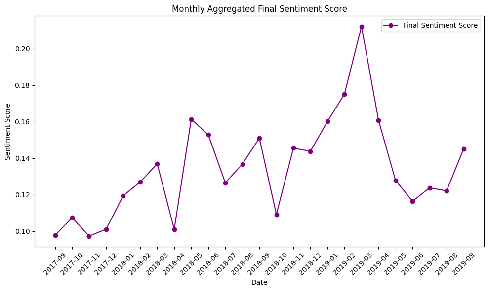

```python
# Monthly aggregation of final_sentiment_score
df_monthly_final = df.groupby(df['Date'].dt.to_period("M")).mean().reset_index()

# Convert 'Date' to string
df_monthly_final['Date'] = df_monthly_final['Date'].astype(str)

# Defining the figure size
plt.figure(figsize=(10, 6))

# Plotting Final Sentiment Score
plt.plot(df_monthly_final['Date'], df_monthly_final['final_sentiment_score'], color='purple', label='Final Sentiment Score', marker='o')
plt.title('Monthly Aggregated Final Sentiment Score')
plt.xlabel('Date')
plt.ylabel('Sentiment Score')
plt.legend()
plt.xticks(rotation=45)  # Rotate x-axis labels

plt.tight_layout()
plt.show()
```

# Feature Engineering

## Sentiment Features

```python
!pip install wordcloud matplotlib
```

```python
import pandas as pd
from wordcloud import WordCloud
import matplotlib.pyplot as plt
from nltk.sentiment import SentimentIntensityAnalyzer
import nltk

nltk.download('vader_lexicon')

# Separate positive and negative words based on the sentiment score
positive_words = ' '.join(df[df['vader_sentiment_score'] > 0]['text'])
negative_words = ' '.join(df[df['vader_sentiment_score'] < 0]['text'])

# Generate WordCloud for positive words
wordcloud_positive = WordCloud(width=800, height=400, background_color='white').generate(positive_words)

# Generate WordCloud for negative words
wordcloud_negative = WordCloud(width=800, height=400, background_color='white').generate(negative_words)
```

[output not shown]

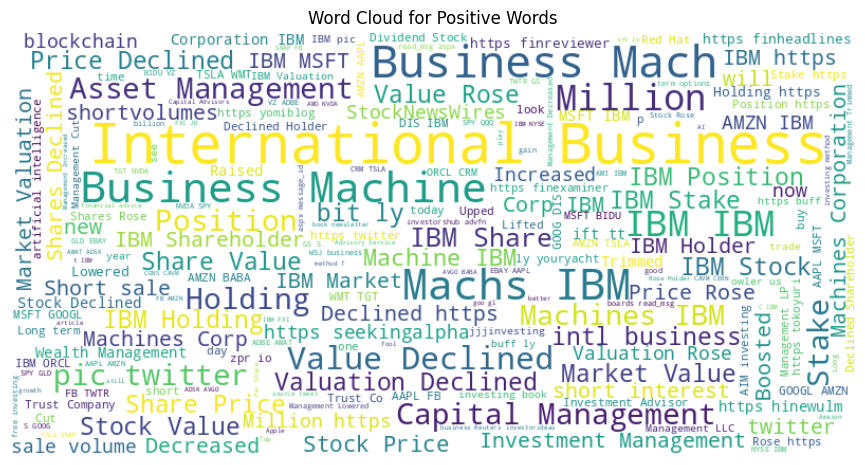

```python
# Plot WordCloud for positive words
plt.figure(figsize=(24, 12))
plt.subplot(1, 2, 1)
plt.imshow(wordcloud_positive, interpolation='bilinear')
plt.title('Word Cloud for Positive Words')
plt.axis('off')
```

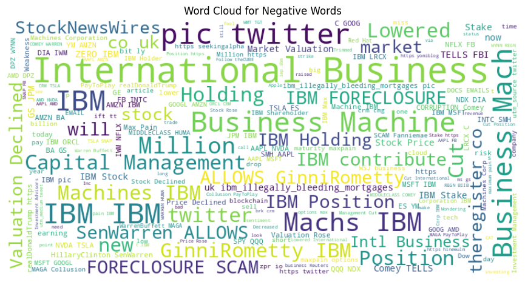

```python
# Plot WordCloud for negative words
plt.figure(figsize=(24, 12))
plt.subplot(1, 2, 2)
plt.imshow(wordcloud_negative, interpolation='bilinear')
plt.title('Word Cloud for Negative Words')
plt.axis('off')

plt.show()
```

## Integer Linguistic Features

```python
# Function for counting the exclamation and question marks in the text
def count_continuous_punctuation(text, punctuation):
    # Count continuous occurrences of the specified punctuation in the text
    pattern = re.compile(f'{re.escape(punctuation)}+')  # Create a regex pattern for continuous occurrences
    matches = re.findall(pattern, text)  # Find all matches in the text
    return len(matches)  # Return the count of continuous occurrences

# Add 'continuous_exclamation' and 'continuous_question' columns to your DataFrame
df['continuous_exclamation'] = df['cleaned_text'].apply(lambda x: count_continuous_punctuation(x, '!'))
# Count continuous exclamation marks in the 'cleaned_text' column and create a new column 'continuous_exclamation'

df['continuous_question'] = df['cleaned_text'].apply(lambda x: count_continuous_punctuation(x, '?'))
# Count continuous question marks in the 'cleaned_text' column and create a new column 'continuous_question'
```

```python
# Function for finding continuous Capital Words because they represent some important information
def count_capitalized_words(text):
    # Count the number of capitalized words in the text
    words = text.split()  # Split the text into a list of words
    capitalized_words = [word for word in words if word.isupper()]  # Create a list of capitalized words
    return len(capitalized_words)  # Return the count of capitalized words

# Add 'capitalized_words' column to your DataFrame
df['capitalized_words'] = df['text'].apply(count_capitalized_words)
```

```python
# Funtion to count the dollar signs as they represent the high raise/decrease in stock
def count_dollar_signs(text):
    # Count the number of dollar signs in the text
    return text.count('$')

# Apply to my df
df['dollar_signs'] = df['text'].apply(count_dollar_signs)
```

```python
# Counting hashtags to understand the importance of versatility of the posts
def count_hashtags(text):
  return text.count('#')


df['num_hashtags'] = df['text'].apply(count_hashtags)
```

```python
# Checking the word count of each sentence
from nltk.tokenize import word_tokenize
from tqdm import tqdm  # showing progress

tqdm.pandas()  # for showing progress


# convert text to string
df['cleaned_text'] = df['cleaned_text'].astype(str)

# Tokenize the cleaned_text column
df['tokens'] = df['cleaned_text'].progress_apply(word_tokenize)

# Calculate word count for each row
df['word_count'] = df['tokens'].apply(len)

# Group by Date and sum the word counts
word_count_by_date = df.groupby('Date')['word_count'].sum().reset_index()
```

## Plotting Features

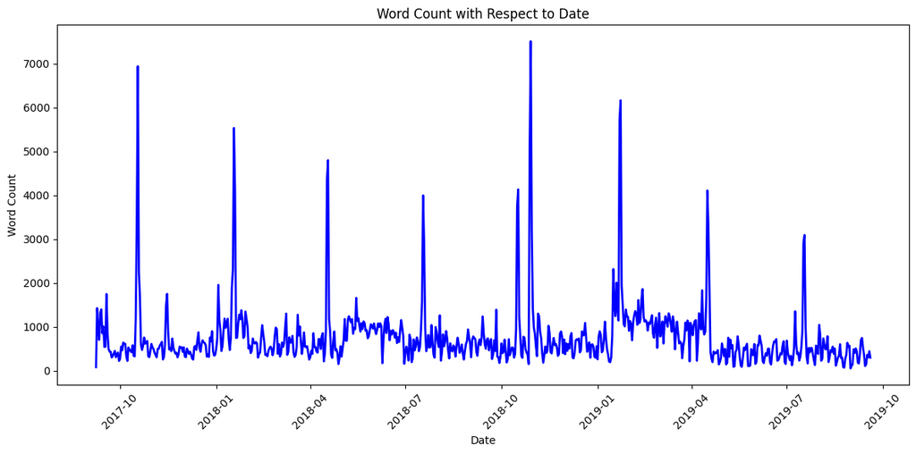

```python
# Plot the word count with respect to Date using a line graph (no points)
plt.figure(figsize=(12, 6))
plt.plot(word_count_by_date['Date'], word_count_by_date['word_count'], linestyle='-', linewidth=2, color='blue')
plt.title('Word Count with Respect to Date')
plt.xlabel('Date')
plt.ylabel('Word Count')
plt.xticks(rotation=45)
plt.tight_layout()
plt.show()
```

Plotting the Integer Features Count

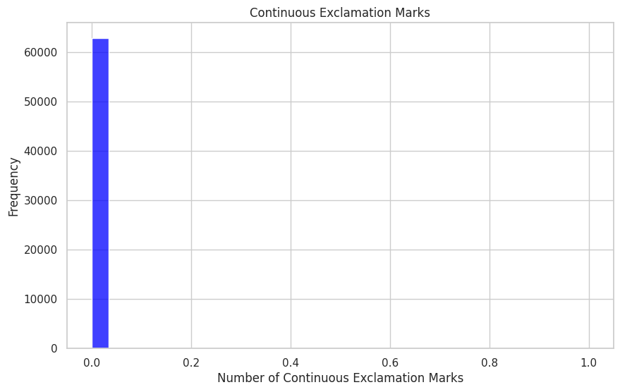

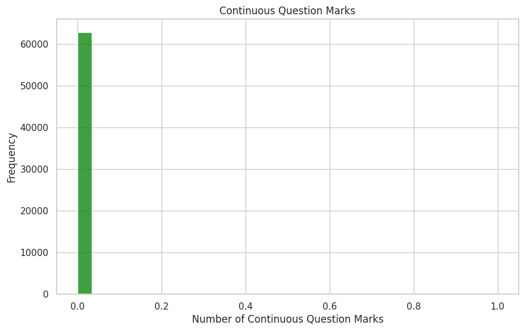

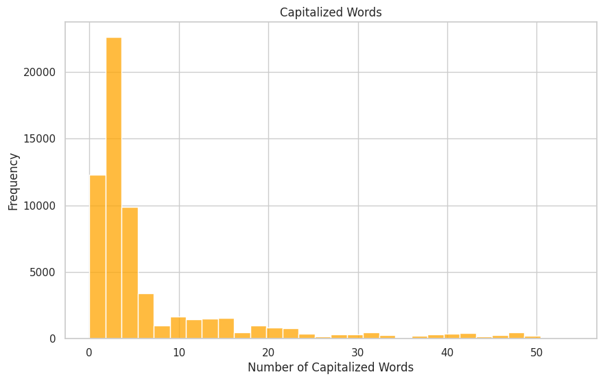

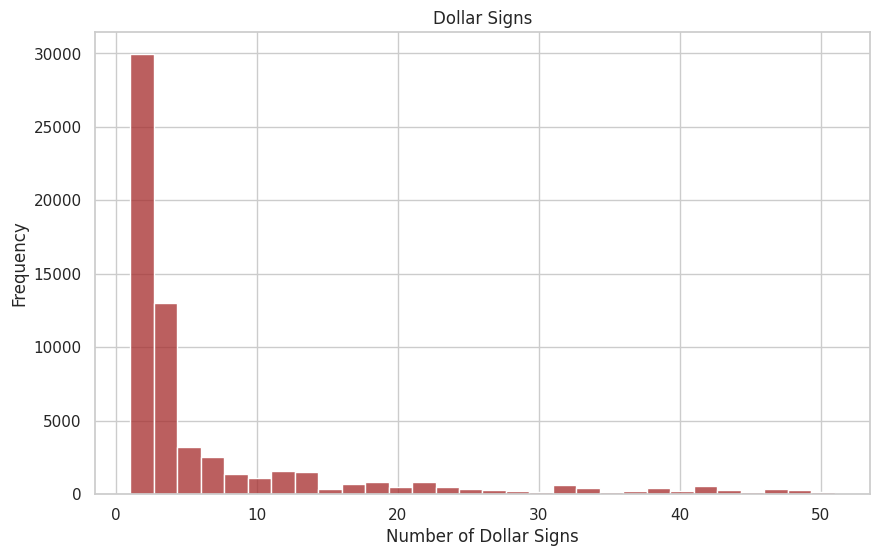

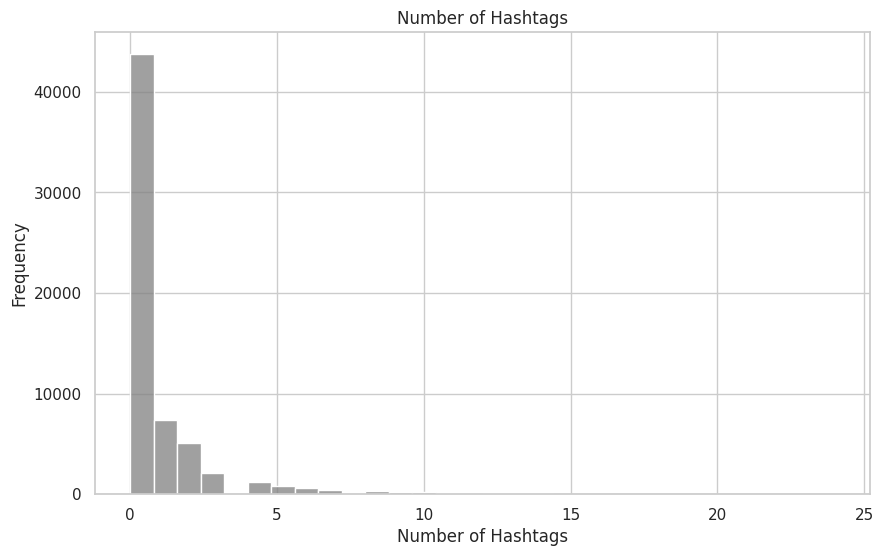

```python
import matplotlib.pyplot as plt
import seaborn as sns

# Set the style for seaborn
sns.set(style="whitegrid")

# Plot continuous exclamation marks
plt.figure(figsize=(10, 6))
sns.histplot(df['continuous_exclamation'], bins=30, kde=False, color='blue')
plt.title('Continuous Exclamation Marks')
plt.xlabel('Number of Continuous Exclamation Marks')
plt.ylabel('Frequency')
plt.show()

# Plot continuous question marks
plt.figure(figsize=(10, 6))
sns.histplot(df['continuous_question'], bins=30, kde=False, color='green')
plt.title('Continuous Question Marks')
plt.xlabel('Number of Continuous Question Marks')
plt.ylabel('Frequency')
plt.show()

# Plot capitalized words
plt.figure(figsize=(10, 6))
sns.histplot(df['capitalized_words'], bins=30, kde=False, color='orange')
plt.title('Capitalized Words')
plt.xlabel('Number of Capitalized Words')
plt.ylabel('Frequency')
plt.show()


# Plot dollar signs
plt.figure(figsize=(10, 6))
sns.histplot(df['dollar_signs'], bins=30, kde=False, color='brown')
plt.title('Dollar Signs')
plt.xlabel('Number of Dollar Signs')
plt.ylabel('Frequency')
plt.show()

# Plot hashtags
plt.figure(figsize=(10, 6))
sns.histplot(df['num_hashtags'], bins=30, kde=False, color='gray')
plt.title('Number of Hashtags')
plt.xlabel('Number of Hashtags')
plt.ylabel('Frequency')
plt.show()
```

Plotting the Integer Features Count by Date

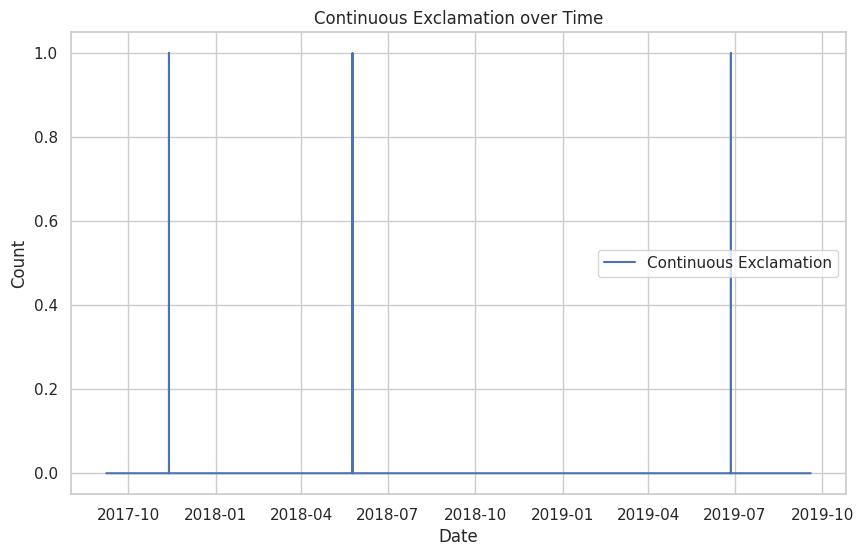

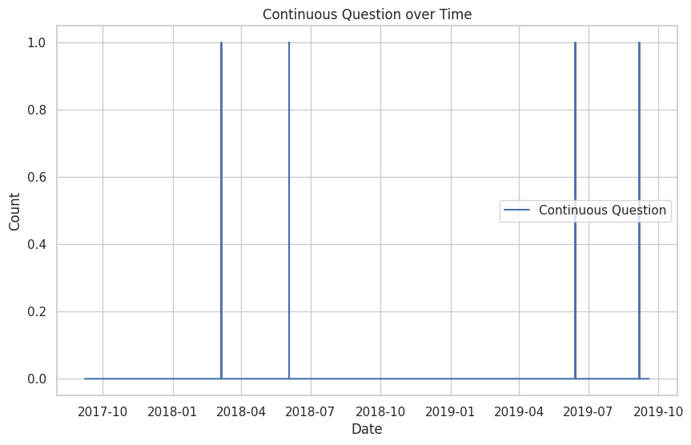

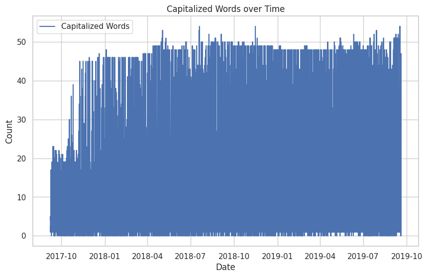

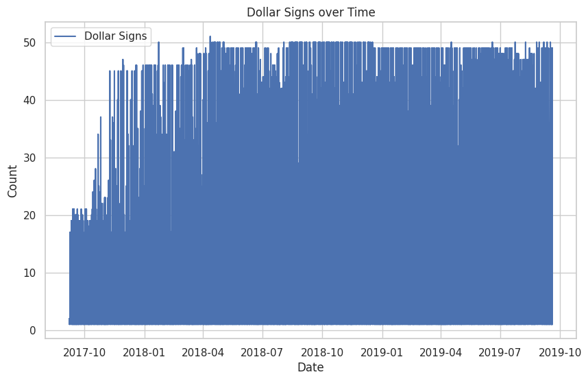

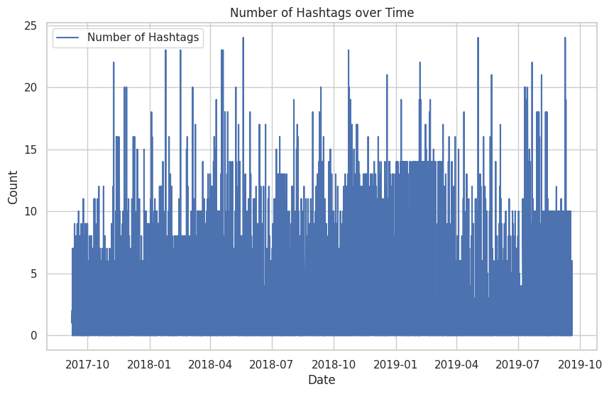

```python
# Plotting continuous_exclamation
plt.figure(figsize=(10, 6))
plt.plot(df['Date'], df['continuous_exclamation'], label='Continuous Exclamation')
plt.title('Continuous Exclamation over Time')
plt.xlabel('Date')
plt.ylabel('Count')
plt.legend()
plt.show()

# Plotting continuous_question
plt.figure(figsize=(10, 6))
plt.plot(df['Date'], df['continuous_question'], label='Continuous Question')
plt.title('Continuous Question over Time')
plt.xlabel('Date')
plt.ylabel('Count')
plt.legend()
plt.show()

# Plotting capitalized_words
plt.figure(figsize=(10, 6))
plt.plot(df['Date'], df['capitalized_words'], label='Capitalized Words')
plt.title('Capitalized Words over Time')
plt.xlabel('Date')
plt.ylabel('Count')
plt.legend()
plt.show()


# Plotting dollar_signs
plt.figure(figsize=(10, 6))
plt.plot(df['Date'], df['dollar_signs'], label='Dollar Signs')
plt.title('Dollar Signs over Time')
plt.xlabel('Date')
plt.ylabel('Count')
plt.legend()
plt.show()

# Plotting num_hashtags
plt.figure(figsize=(10, 6))
plt.plot(df['Date'], df['num_hashtags'], label='Number of Hashtags')
plt.title('Number of Hashtags over Time')
plt.xlabel('Date')
plt.ylabel('Count')
plt.legend()
plt.show()
```

## Likelihood Ratio (LLR)

LLR provides a statistical measure of the strength of association between words, which can be valuable in sentiment analysis by revealing meaningful patterns and helping to extract features for sentiment prediction models.

```python
import nltk
from nltk import collocations
from nltk.tokenize import word_tokenize

nltk.download('punkt')

# Function to calculate Log-Likelihood Ratio for a given text and return the mean
def calculate_mean_llr(text):
    words = word_tokenize(text.lower())
    finder = collocations.BigramCollocationFinder.from_words(words)

    # Filter out bigrams with frequency less than 1
    finder.apply_freq_filter(1)

    try:
        llr_scores = [score for bigram, score in finder.score_ngrams(collocations.BigramAssocMeasures.likelihood_ratio)]
        # Extract LLR scores
        mean_llr = sum(llr_scores) / len(llr_scores) if llr_scores else 0
        # Calculate the mean of the LLR scores, handling the case where llr_scores is empty
    except ValueError:
        # Handle math domain error by returning 0 for problematic cases
        mean_llr = 0

    return mean_llr

# Apply the function to the 'clean_tweets' column in your DataFrame
df['llr_score'] = df['clean_tweets'].apply(calculate_mean_llr)
```

```python
df.head()
```

|  | Date | author_id | name | text | followers_count | sentiment | polarity | subjectivity | cleaned_text | core_meaning | ... | vader_sentiment_score | TextBlob_sentiment_score | final_sentiment_score | continuous_exclamation | continuous_question | capitalized_words | dollar_signs | num_hashtags | word_count | llr_score |
| --- | --- | --- | --- | --- | --- | --- | --- | --- | --- | --- | --- | --- | --- | --- | --- | --- | --- | --- | --- | --- | --- |
| 0 | 2017-09-08 | 4825963711 | Software News | #IBM #and MIT team up to launch an AI lab set ... | 915.0 | 1 | 0.50 | 0.50 | MIT team launch AI lab set make Watson even sm... | MIT team launch AI lab set make Watson even sm... | ... | 0.4588 | 0.0 | 0.32116 | 0 | 0 | 4 | 1 | 2 | 11 | 6.701994 |
| 1 | 2017-09-08 | 4825027321 | IT Services News | #IBM #to invest $240 million to advance artifi... | 1441.0 | -1 | -0.05 | 0.75 | invest million advance artificial intelligen... | invest million advance artificial intelligen... | ... | 0.4767 | -0.6 | 0.15369 | 0 | 0 | 4 | 2 | 2 | 11 | 6.701994 |
| 2 | 2017-09-08 | 4825027321 | IT Services News | #IBM #To Invest $240M In AI Lab From MIT. Read... | 1441.0 | 1 | 0.50 | 0.50 | Invest M AI Lab MIT Read | Invest M AI Lab MIT Read | ... | 0.0000 | 0.0 | 0.00000 | 0 | 0 | 5 | 2 | 2 | 6 | 5.004024 |
| 3 | 2017-09-08 | 706297891070087168 | OptionsPro MaxPain | #Options #maxpain chart for $IBM. Free options... | 3077.0 | 1 | 0.40 | 0.80 | chart Free option app | chart Free option app | ... | 0.5106 | 0.4 | 0.47742 | 0 | 0 | 1 | 1 | 2 | 4 | 4.498681 |
| 4 | 2017-09-08 | 4825027321 | IT Services News | #IBM #and MIT team up to launch an AI lab set ... | 1441.0 | 1 | 0.50 | 0.50 | MIT team launch AI lab set make Watson even sm... | MIT team launch AI lab set make Watson even sm... | ... | 0.4588 | 0.0 | 0.32116 | 0 | 0 | 4 | 1 | 2 | 11 | 6.701994 |

5 rows × 22 columns

# Correlation Heatmap

Plotting the Correlation Heatmap to understand the relationship between features

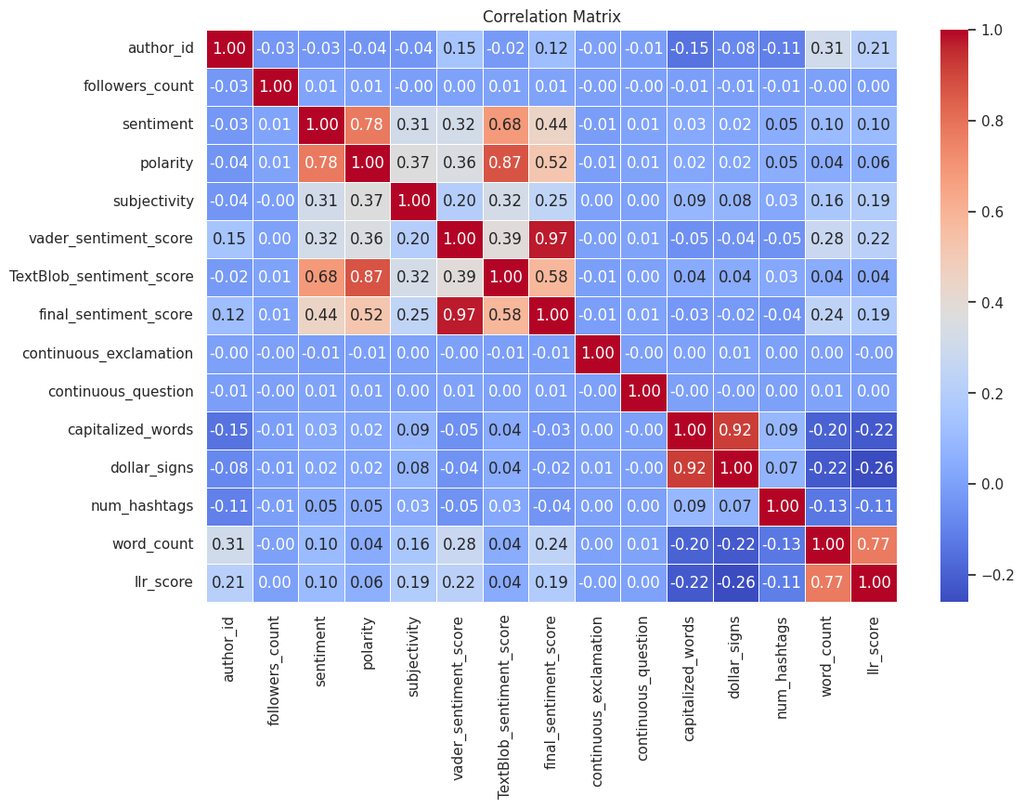

```python
import pandas as pd
import seaborn as sns
import matplotlib.pyplot as plt

# Remove non-numeric columns, as correlation is applicable to numeric data
numeric_columns = df.select_dtypes(include=['float64', 'int64']).columns
correlation_matrix = df[numeric_columns].corr()

# Set up the matplotlib figure size
plt.figure(figsize=(12, 8))

# Plot the correlation matrix as a heatmap
sns.heatmap(correlation_matrix, annot=True, cmap='coolwarm', fmt='.2f', linewidths=.5)

# Showing the plot
plt.title('Correlation Matrix')
plt.show()
```

# Sentiment Score Analysis

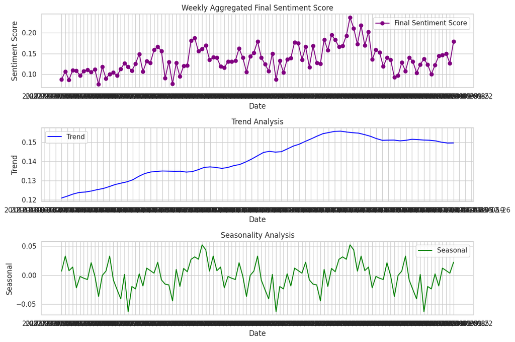

```python
from statsmodels.tsa.seasonal import seasonal_decompose

# Weekly aggregation of final_sentiment_score
df_weekly_final = df.groupby(df['Date'].dt.to_period("W")).mean().reset_index()

# Convert 'Date' to string
df_weekly_final['Date'] = df_weekly_final['Date'].astype(str)

# Defining the figure size
plt.figure(figsize=(12, 8))

# Plotting Final Sentiment Score
plt.subplot(3, 1, 1)
plt.plot(df_weekly_final['Date'], df_weekly_final['final_sentiment_score'], color='purple', label='Final Sentiment Score', marker='o')
plt.title('Weekly Aggregated Final Sentiment Score')
plt.xlabel('Date')
plt.ylabel('Sentiment Score')
plt.legend()
plt.xticks

# Perform time series decomposition with a reduced period
result = seasonal_decompose(df_weekly_final['final_sentiment_score'], model='additive', period=40)  # adjust period based on available data

# Plotting Trend component
plt.subplot(3, 1, 2)
plt.plot(df_weekly_final['Date'], result.trend, color='blue', label='Trend')
plt.title('Trend Analysis')
plt.xlabel('Date')
plt.ylabel('Trend')
plt.legend()
plt.xticks

# Plotting Seasonal component
plt.subplot(3, 1, 3)
plt.plot(df_weekly_final['Date'], result.seasonal, color='green', label='Seasonal')
plt.title('Seasonality Analysis')
plt.xlabel('Date')
plt.ylabel('Seasonal')
plt.legend()
plt.xticks

plt.tight_layout()
plt.show()
```

## Residuals/Noise

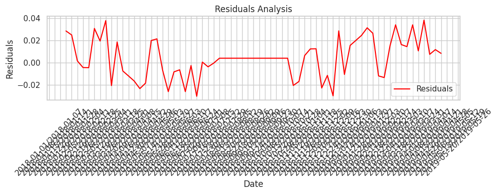

```python
# Weekly aggregation of final_sentiment_score
df_weekly_final = df.groupby(df['Date'].dt.to_period("W")).mean().reset_index()

# Convert 'Date' to string
df_weekly_final['Date'] = df_weekly_final['Date'].astype(str)

# Perform time series decomposition with a reduced period
result = seasonal_decompose(df_weekly_final['final_sentiment_score'], model='additive', period=40)  # adjust period based on available data

# Calculate residuals (noise)
residuals = df_weekly_final['final_sentiment_score'] - result.trend - result.seasonal

# Plot Residuals
plt.figure(figsize=(10, 4))
plt.plot(df_weekly_final['Date'], residuals, color='red', label='Residuals')
plt.title('Residuals Analysis')
plt.xlabel('Date')
plt.ylabel('Residuals')
plt.legend()
plt.xticks(rotation=45)
plt.tight_layout()
plt.show()
```

## Autocorrelation

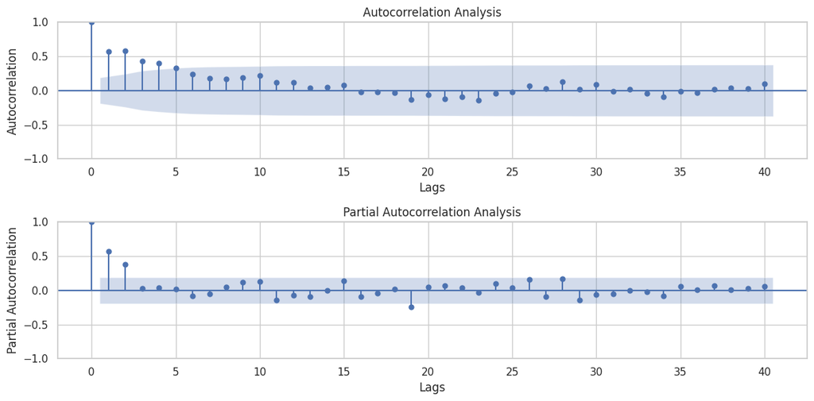

```python
from statsmodels.graphics.tsaplots import plot_acf, plot_pacf

# Plot Autocorrelation and Partial Autocorrelation
plt.figure(figsize=(12, 6))

# Autocorrelation plot
plt.subplot(2, 1, 1)
plot_acf(df_weekly_final['final_sentiment_score'], lags=40, ax=plt.gca())
plt.title('Autocorrelation Analysis')
plt.xlabel('Lags')
plt.ylabel('Autocorrelation')

# Partial Autocorrelation plot
plt.subplot(2, 1, 2)
plot_pacf(df_weekly_final['final_sentiment_score'], lags=40, ax=plt.gca())
plt.title('Partial Autocorrelation Analysis')
plt.xlabel('Lags')
plt.ylabel('Partial Autocorrelation')

plt.tight_layout()
plt.show()
```

## Rolling Statistics (Volatility)

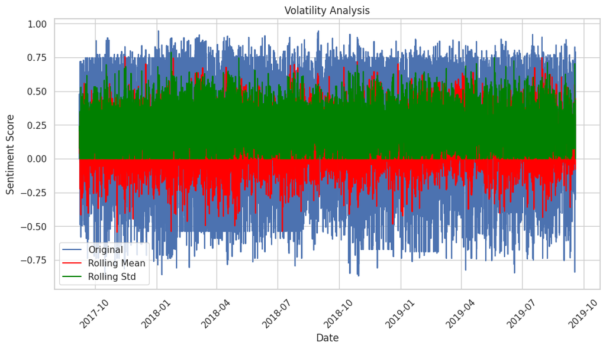

```python
# Calculate rolling mean and rolling standard deviation
rolling_mean = df['final_sentiment_score'].rolling(window=4).mean()  # adjust window size based on available data
rolling_std = df['final_sentiment_score'].rolling(window=4).std()

# Plotting Rolling Mean and Rolling Standard Deviation
plt.figure(figsize=(12, 6))
plt.plot(df['Date'], df['final_sentiment_score'], label='Original')
plt.plot(df['Date'], rolling_mean, label='Rolling Mean', color='red')
plt.plot(df['Date'], rolling_std, label='Rolling Std', color='green')
plt.title('Volatility Analysis')
plt.xlabel('Date')
plt.ylabel('Sentiment Score')
plt.legend()
plt.xticks(rotation=45)
plt.show()
```

## Stationarity

```
ADF Statistic: -3.142846450970038
p-value: 0.023540607563374973
Critical Values: {'1%': -3.4942202045135513, '5%': -2.889485291005291, '10%': -2.5816762131519275}
```

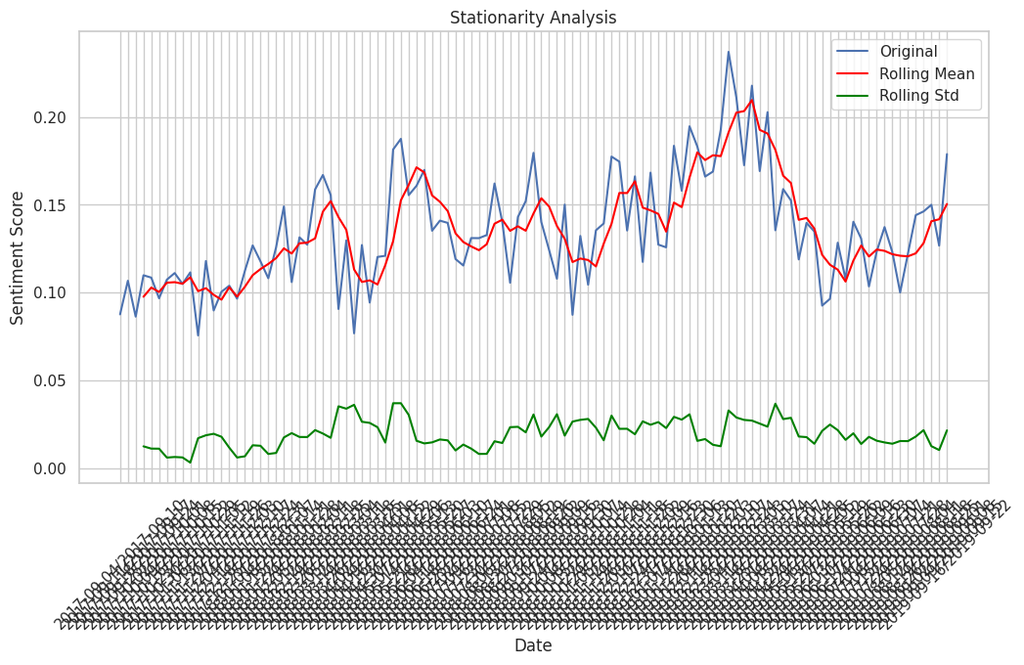

```python
from statsmodels.tsa.stattools import adfuller

# Perform ADF test for stationarity
result_adf = adfuller(df_weekly_final['final_sentiment_score'])
print(f'ADF Statistic: {result_adf[0]}')
print(f'p-value: {result_adf[1]}')
print(f'Critical Values: {result_adf[4]}')

# You can also visualize the rolling mean and rolling standard deviation
rolling_mean = df_weekly_final['final_sentiment_score'].rolling(window=4).mean()  # adjust window size based on available data
rolling_std = df_weekly_final['final_sentiment_score'].rolling(window=4).std()

# Plotting Rolling Mean and Rolling Standard Deviation
plt.figure(figsize=(12, 6))
plt.plot(df_weekly_final['Date'], df_weekly_final['final_sentiment_score'], label='Original')
plt.plot(df_weekly_final['Date'], rolling_mean, label='Rolling Mean', color='red')
plt.plot(df_weekly_final['Date'], rolling_std, label='Rolling Std', color='green')
plt.title('Stationarity Analysis')
plt.xlabel('Date')
plt.ylabel('Sentiment Score')
plt.legend()
plt.xticks(rotation=45)
plt.show()
```

## Periodogram

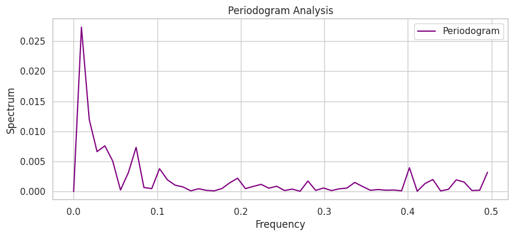

```python
from scipy.signal import periodogram

# Calculate the periodogram
frequencies, spectrum = periodogram(df_weekly_final['final_sentiment_score'])

# Plot the periodogram
plt.figure(figsize=(10, 4))
plt.plot(frequencies, spectrum, color='purple', label='Periodogram')
plt.title('Periodogram Analysis')
plt.xlabel('Frequency')
plt.ylabel('Spectrum')
plt.legend()
plt.show()
```

# Saving DF as csv

```python
#Saving the df into a csv
df.to_csv("IBM_P1.csv", index=False)
```

# **Stock Data Analysis** **(Part - 2)**

# Importing Libraries and Extracting data

```python
stock_symbol = 'IBM'
```

```python
import yfinance as yf

# Set the stock symbol and date range

start_date = user_start_date
end_date = user_end_date

# Download historical stock data from Yahoo Finance
stock_data = yf.download(stock_symbol, start=start_date, end=end_date)

# Reset index to have 'Date' as a column
stock_data.reset_index(inplace=True)

# Reorder columns to match the specified format
stock_data = stock_data[['Date', 'Open', 'High', 'Low', 'Close', 'Adj Close', 'Volume']]
```

```
[*********************100%%**********************]  1 of 1 completed
```

```python
stock_data.head()
```

|  | Date | Open | High | Low | Close | Adj Close | Volume |
| --- | --- | --- | --- | --- | --- | --- | --- |
| 0 | 2017-09-08 | 136.854691 | 136.854691 | 135.411087 | 136.185471 | 101.079407 | 3521045 |
| 1 | 2017-09-11 | 137.227539 | 138.747604 | 136.720840 | 138.489487 | 102.789444 | 4825616 |
| 2 | 2017-09-12 | 138.728485 | 139.933075 | 138.154877 | 139.349899 | 103.428101 | 5479053 |
| 3 | 2017-09-13 | 138.957932 | 139.856598 | 138.948380 | 139.569794 | 103.591301 | 4289646 |
| 4 | 2017-09-14 | 139.445511 | 139.942642 | 139.110901 | 139.139572 | 103.271980 | 3929717 |

```python
stock_data.shape
```

```
(510, 7)
```

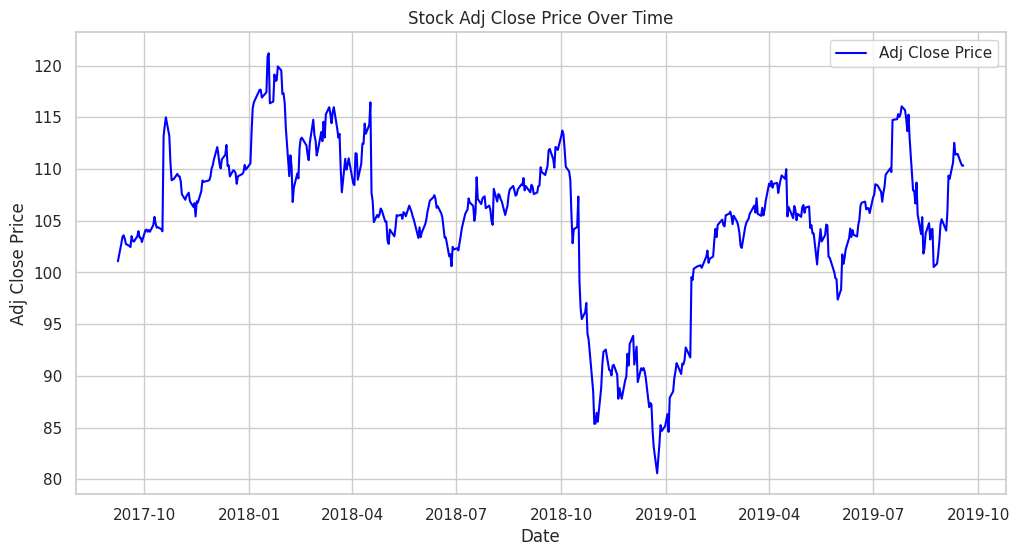

```python
import matplotlib.pyplot as plt

# Assuming 'final_df' is your DataFrame
plt.figure(figsize=(12, 6))
plt.plot(stock_data['Date'], stock_data['Adj Close'], label='Adj Close Price', color='blue')
plt.title('Stock Adj Close Price Over Time')
plt.xlabel('Date')
plt.ylabel('Adj Close Price')
plt.legend()
plt.show()
```